# RedwineData Exploration by Xin Meng

This report explores a dataset containing physicochemical properties and quality of 1599 samples of red wine.

```
##  [1] "X"                    "fixed.acidity"        "volatile.acidity"
##  [4] "citric.acid"          "residual.sugar"       "chlorides"
##  [7] "free.sulfur.dioxide"  "total.sulfur.dioxide" "density"
## [10] "pH"                   "sulphates"            "alcohol"
## [13] "quality"
```

```
##   X fixed.acidity volatile.acidity citric.acid residual.sugar chlorides
## 1 1           7.4             0.70        0.00            1.9     0.076
## 2 2           7.8             0.88        0.00            2.6     0.098
## 3 3           7.8             0.76        0.04            2.3     0.092
## 4 4          11.2             0.28        0.56            1.9     0.075
## 5 5           7.4             0.70        0.00            1.9     0.076
## 6 6           7.4             0.66        0.00            1.8     0.075
##   free.sulfur.dioxide total.sulfur.dioxide density   pH sulphates alcohol
## 1                  11                   34  0.9978 3.51      0.56     9.4
## 2                  25                   67  0.9968 3.20      0.68     9.8
## 3                  15                   54  0.9970 3.26      0.65     9.8
## 4                  17                   60  0.9980 3.16      0.58     9.8
## 5                  11                   34  0.9978 3.51      0.56     9.4
## 6                  13                   40  0.9978 3.51      0.56     9.4
##   quality
## 1       5
## 2       5
## 3       5
## 4       6
## 5       5
## 6       5
```

# Univariate Plots Section

Our dataset consists of 13 variables, with 1599 observations.There’s no NAs in the dataset.

```
## [1] 1599   13
```

```
## 'data.frame':    1599 obs. of  13 variables:
##  $ X                   : int  1 2 3 4 5 6 7 8 9 10 ...
##  $ fixed.acidity       : num  7.4 7.8 7.8 11.2 7.4 7.4 7.9 7.3 7.8 7.5 ...
##  $ volatile.acidity    : num  0.7 0.88 0.76 0.28 0.7 0.66 0.6 0.65 0.58 0.5 ...
##  $ citric.acid         : num  0 0 0.04 0.56 0 0 0.06 0 0.02 0.36 ...
##  $ residual.sugar      : num  1.9 2.6 2.3 1.9 1.9 1.8 1.6 1.2 2 6.1 ...
##  $ chlorides           : num  0.076 0.098 0.092 0.075 0.076 0.075 0.069 0.065 0.073 0.071 ...
##  $ free.sulfur.dioxide : num  11 25 15 17 11 13 15 15 9 17 ...
##  $ total.sulfur.dioxide: num  34 67 54 60 34 40 59 21 18 102 ...
##  $ density             : num  0.998 0.997 0.997 0.998 0.998 ...
##  $ pH                  : num  3.51 3.2 3.26 3.16 3.51 3.51 3.3 3.39 3.36 3.35 ...
##  $ sulphates           : num  0.56 0.68 0.65 0.58 0.56 0.56 0.46 0.47 0.57 0.8 ...
##  $ alcohol             : num  9.4 9.8 9.8 9.8 9.4 9.4 9.4 10 9.5 10.5 ...
##  $ quality             : int  5 5 5 6 5 5 5 7 7 5 ...
```

```
##        X          fixed.acidity   volatile.acidity  citric.acid
##  Min.   :   1.0   Min.   : 4.60   Min.   :0.1200   Min.   :0.000
##  1st Qu.: 400.5   1st Qu.: 7.10   1st Qu.:0.3900   1st Qu.:0.090
##  Median : 800.0   Median : 7.90   Median :0.5200   Median :0.260
##  Mean   : 800.0   Mean   : 8.32   Mean   :0.5278   Mean   :0.271
##  3rd Qu.:1199.5   3rd Qu.: 9.20   3rd Qu.:0.6400   3rd Qu.:0.420
##  Max.   :1599.0   Max.   :15.90   Max.   :1.5800   Max.   :1.000
##  residual.sugar     chlorides       free.sulfur.dioxide
##  Min.   : 0.900   Min.   :0.01200   Min.   : 1.00
##  1st Qu.: 1.900   1st Qu.:0.07000   1st Qu.: 7.00
##  Median : 2.200   Median :0.07900   Median :14.00
##  Mean   : 2.539   Mean   :0.08747   Mean   :15.87
##  3rd Qu.: 2.600   3rd Qu.:0.09000   3rd Qu.:21.00
##  Max.   :15.500   Max.   :0.61100   Max.   :72.00
##  total.sulfur.dioxide    density             pH          sulphates
##  Min.   :  6.00       Min.   :0.9901   Min.   :2.740   Min.   :0.3300
##  1st Qu.: 22.00       1st Qu.:0.9956   1st Qu.:3.210   1st Qu.:0.5500
##  Median : 38.00       Median :0.9968   Median :3.310   Median :0.6200
##  Mean   : 46.47       Mean   :0.9967   Mean   :3.311   Mean   :0.6581
##  3rd Qu.: 62.00       3rd Qu.:0.9978   3rd Qu.:3.400   3rd Qu.:0.7300
##  Max.   :289.00       Max.   :1.0037   Max.   :4.010   Max.   :2.0000
##     alcohol         quality
##  Min.   : 8.40   Min.   :3.000
##  1st Qu.: 9.50   1st Qu.:5.000
##  Median :10.20   Median :6.000
##  Mean   :10.42   Mean   :5.636
##  3rd Qu.:11.10   3rd Qu.:6.000
##  Max.   :14.90   Max.   :8.000
```

```
## [1] 0
```

Most samples quality scores are 5,6 and 7,fewer samples are less than 5 or more than 7.The quality scores were graded by expert between 0(very bad) and 10(very excellent).That means there are much more normal wines than excellent or poor ones.The distribution is nearly Normal distribution.

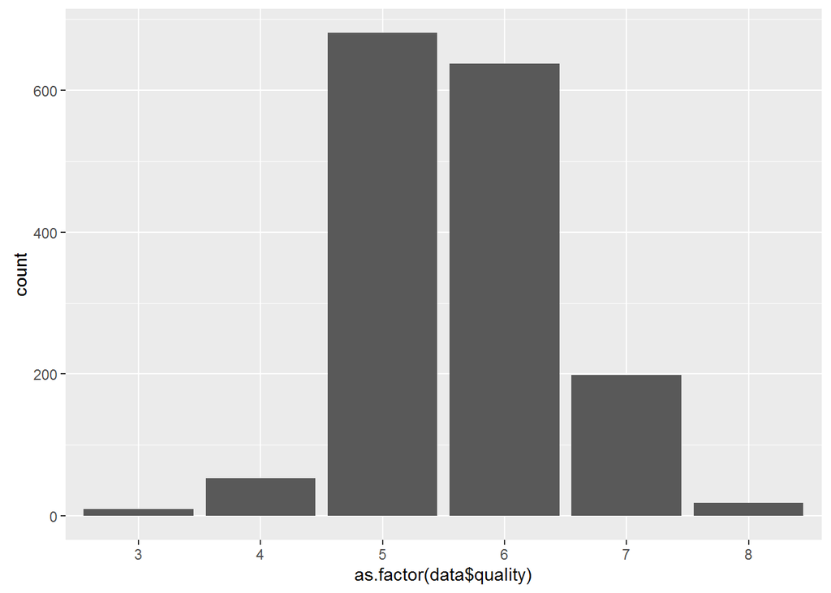

```
##    Min. 1st Qu.  Median    Mean 3rd Qu.    Max.
##   3.000   5.000   6.000   5.636   6.000   8.000
```

Let’s examine the histogram of each feature. We find that most variables are look like normal distribution. Some variables are right skewed.We use log10 transformation with there variables. Fixed.acidity like normal distribution, median is 7.9

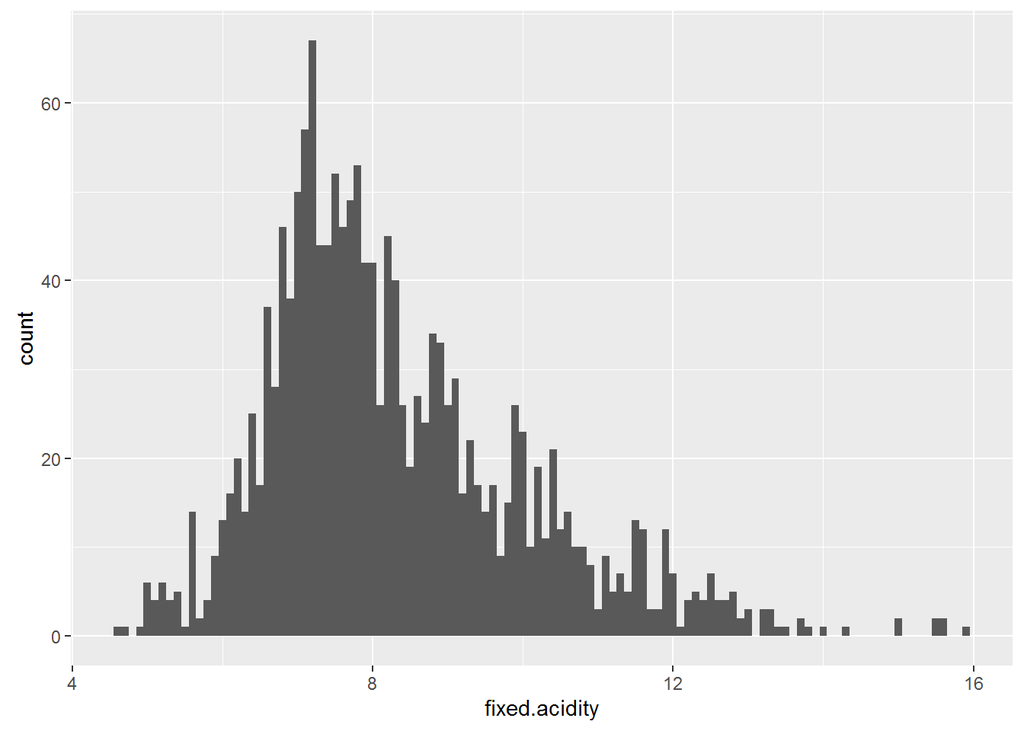

```
##    Min. 1st Qu.  Median    Mean 3rd Qu.    Max.
##    4.60    7.10    7.90    8.32    9.20   15.90
```

Volatile.acidity like normal distribution,median is 0.52.But it seems have two peak.

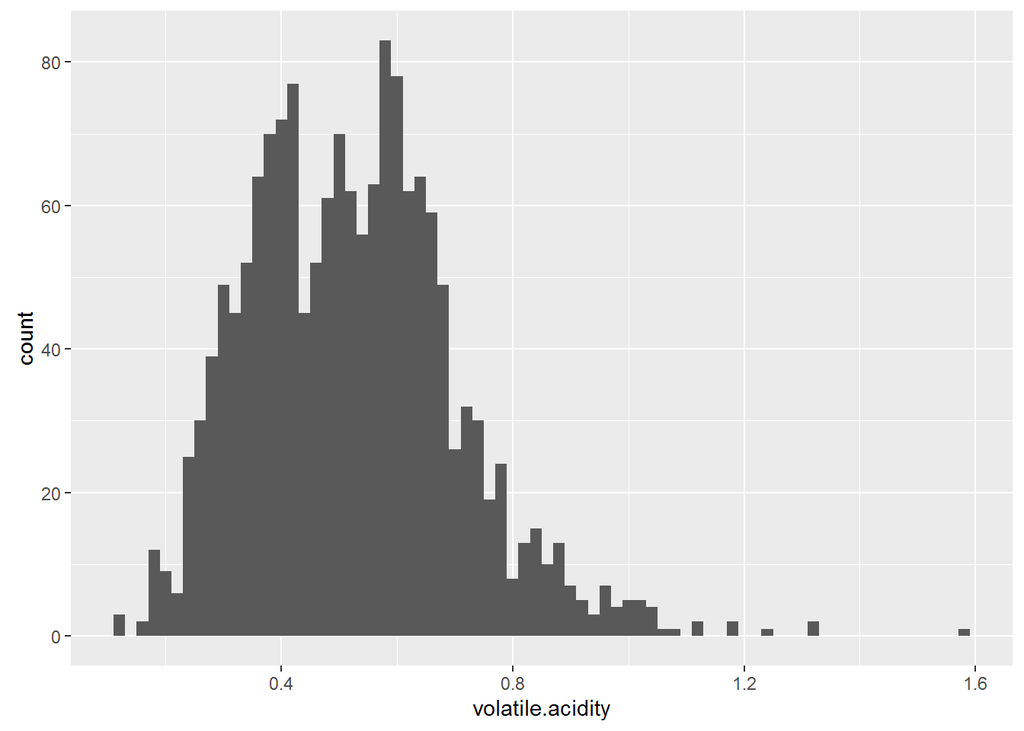

```
##    Min. 1st Qu.  Median    Mean 3rd Qu.    Max.
##  0.1200  0.3900  0.5200  0.5278  0.6400  1.5800
```

Citric.acid looks like uniform, with 75% samples less than 0.42.There’re 132 samples have citric.acid=0.

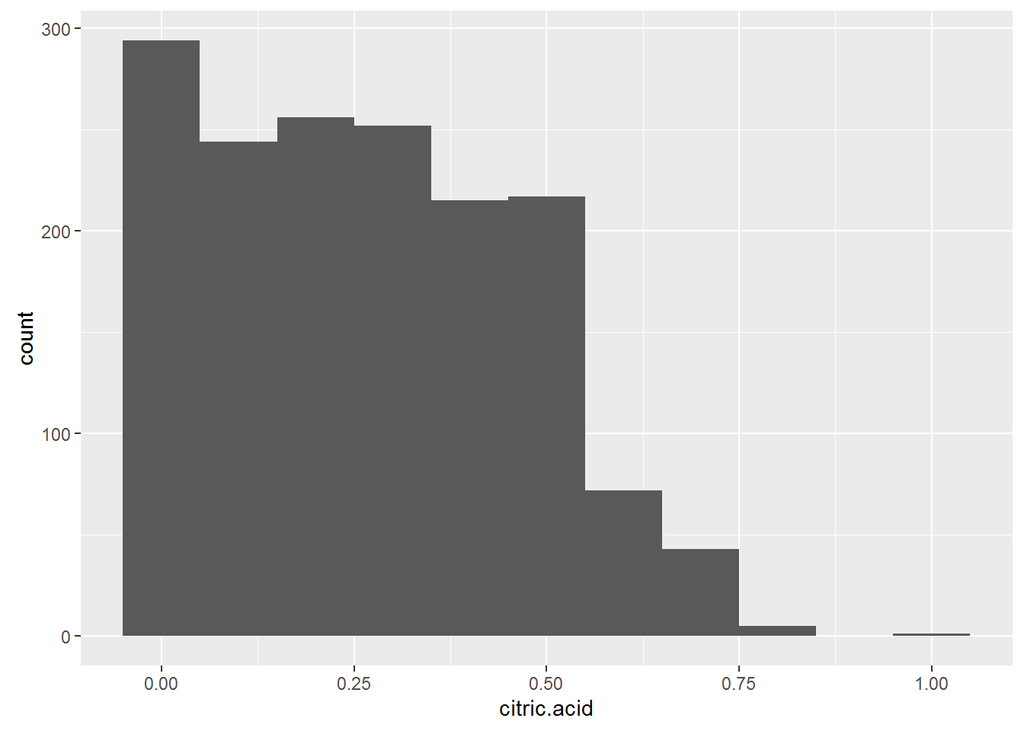

```
##    Min. 1st Qu.  Median    Mean 3rd Qu.    Max.
##   0.000   0.090   0.260   0.271   0.420   1.000
```

```
##
## FALSE  TRUE
##  1467   132
```

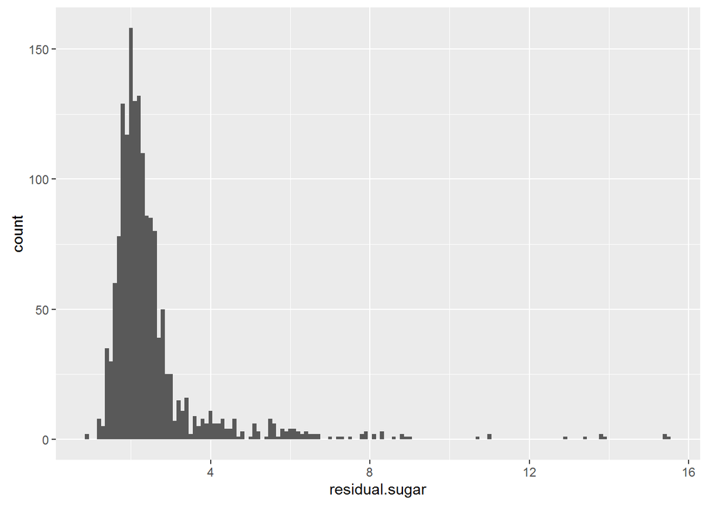

```
##    Min. 1st Qu.  Median    Mean 3rd Qu.    Max.
##   0.900   1.900   2.200   2.539   2.600  15.500
```

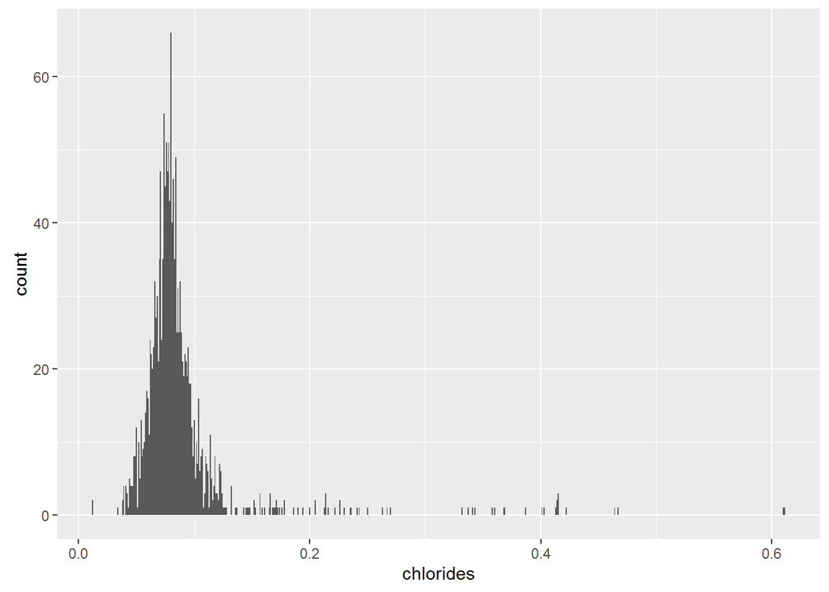

```
##    Min. 1st Qu.  Median    Mean 3rd Qu.    Max.
## 0.01200 0.07000 0.07900 0.08747 0.09000 0.61100
```

Free.sulfur.dioxide has right long tail, median is 14.0, using log10 transformation and get normal like distribution.

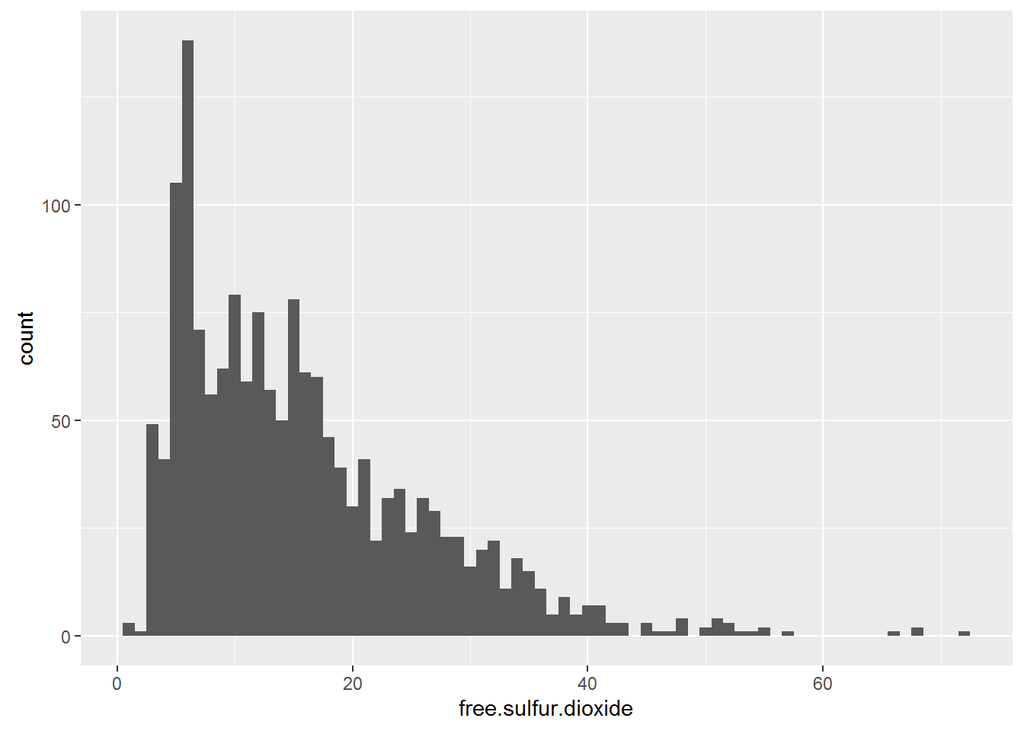

```
##    Min. 1st Qu.  Median    Mean 3rd Qu.    Max.
##    1.00    7.00   14.00   15.87   21.00   72.00
```

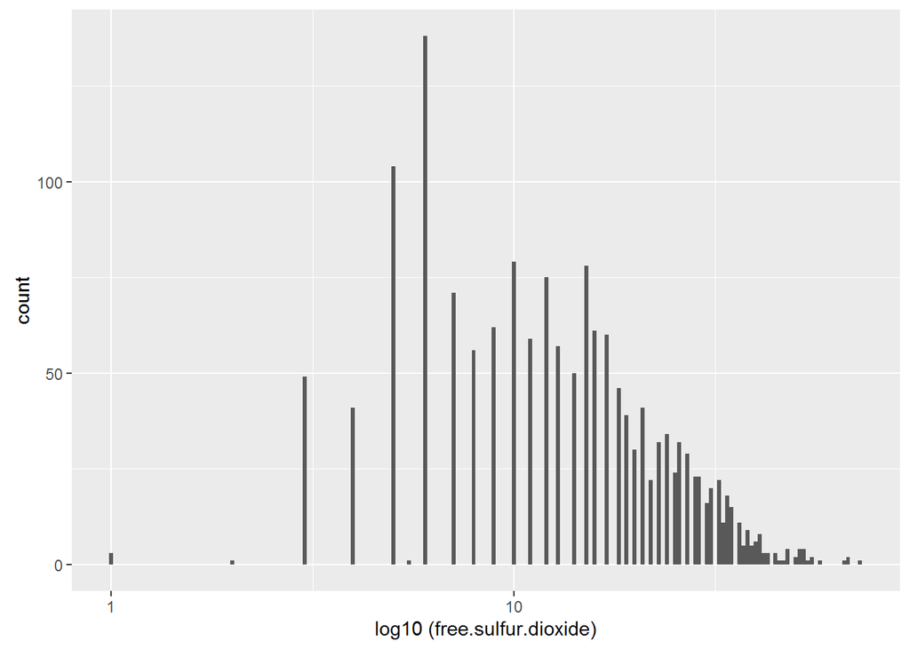

Total.sulfur.dioxide has right long tail, median is 38.0, using log10 transformation and get normal like distribution.

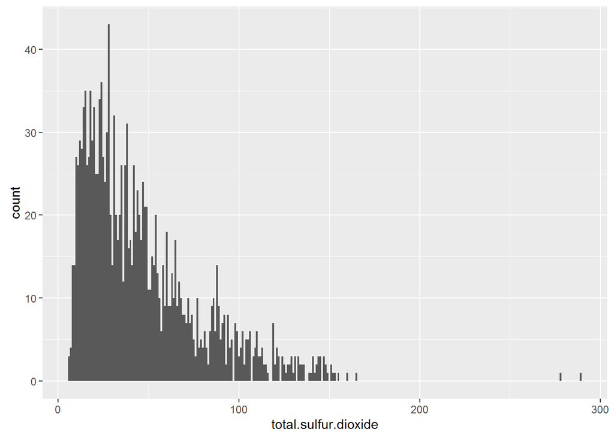

```
##    Min. 1st Qu.  Median    Mean 3rd Qu.    Max.
##    6.00   22.00   38.00   46.47   62.00  289.00
```

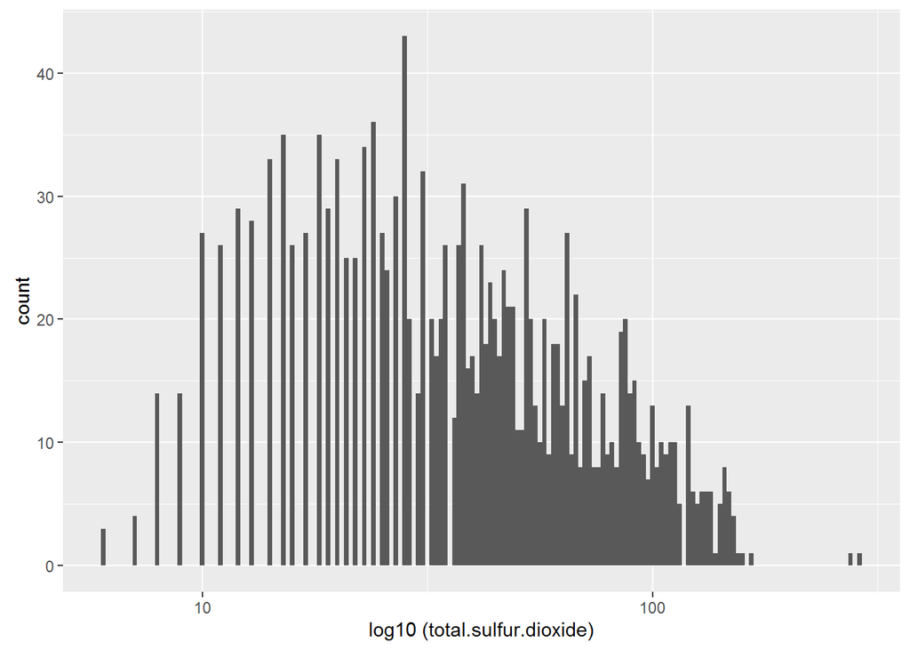

Density has normal like distribution.median is 0.9968.

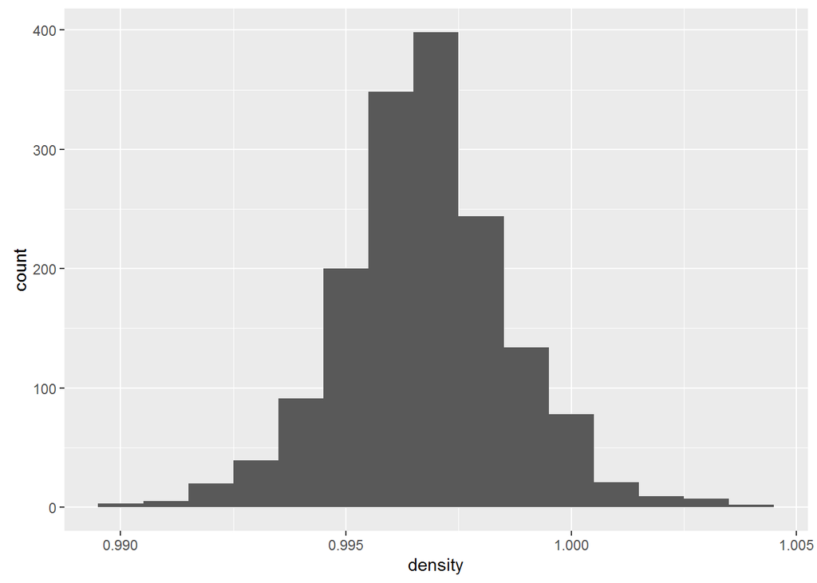

```
##    Min. 1st Qu.  Median    Mean 3rd Qu.    Max.
##  0.9901  0.9956  0.9968  0.9967  0.9978  1.0040
```

pH has normal like distribution,median is 3.31

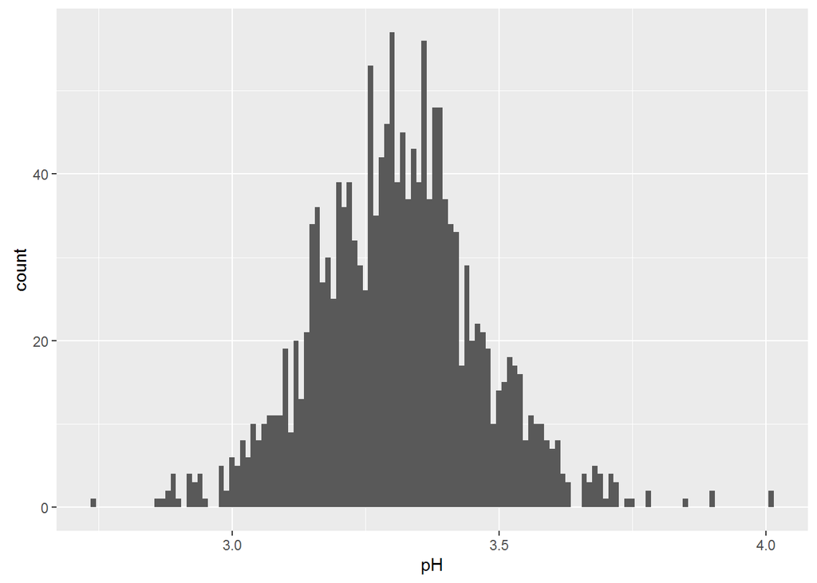

```
##    Min. 1st Qu.  Median    Mean 3rd Qu.    Max.
##   2.740   3.210   3.310   3.311   3.400   4.010
```

Sulphates has normal like distribution, median is 0.62

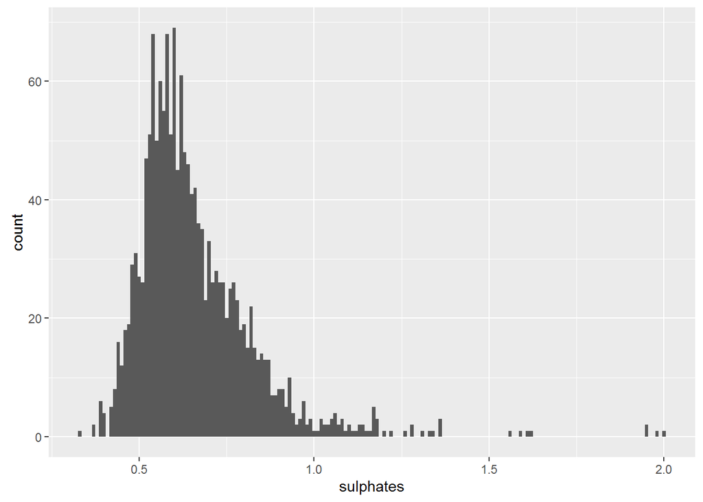

```
##    Min. 1st Qu.  Median    Mean 3rd Qu.    Max.
##  0.3300  0.5500  0.6200  0.6581  0.7300  2.0000
```

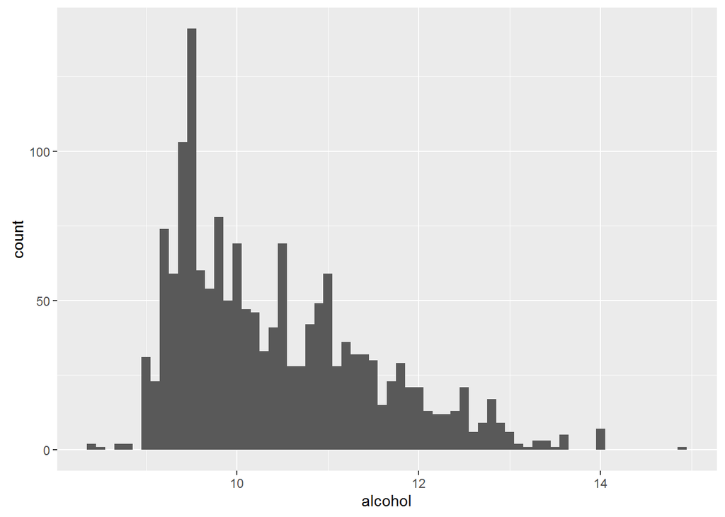

```
##    Min. 1st Qu.  Median    Mean 3rd Qu.    Max.
##    8.40    9.50   10.20   10.42   11.10   14.90
```

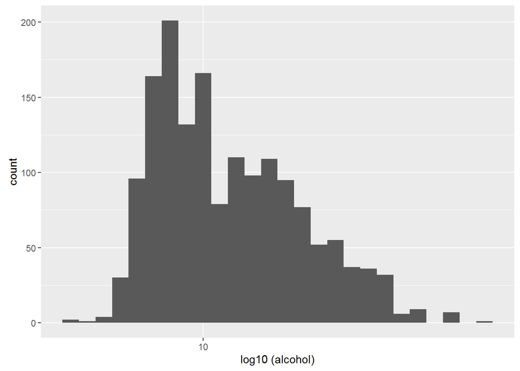

I created a new feature of ratioacidity=volatile acidity/fixed acidity. The histogram of ratioacidity has a normal like distribution, and have 2 peaks like volatile.acidity.

```
##    Min. 1st Qu.  Median    Mean 3rd Qu.    Max.
## 0.01348 0.04405 0.06569 0.06706 0.08581 0.20800
```

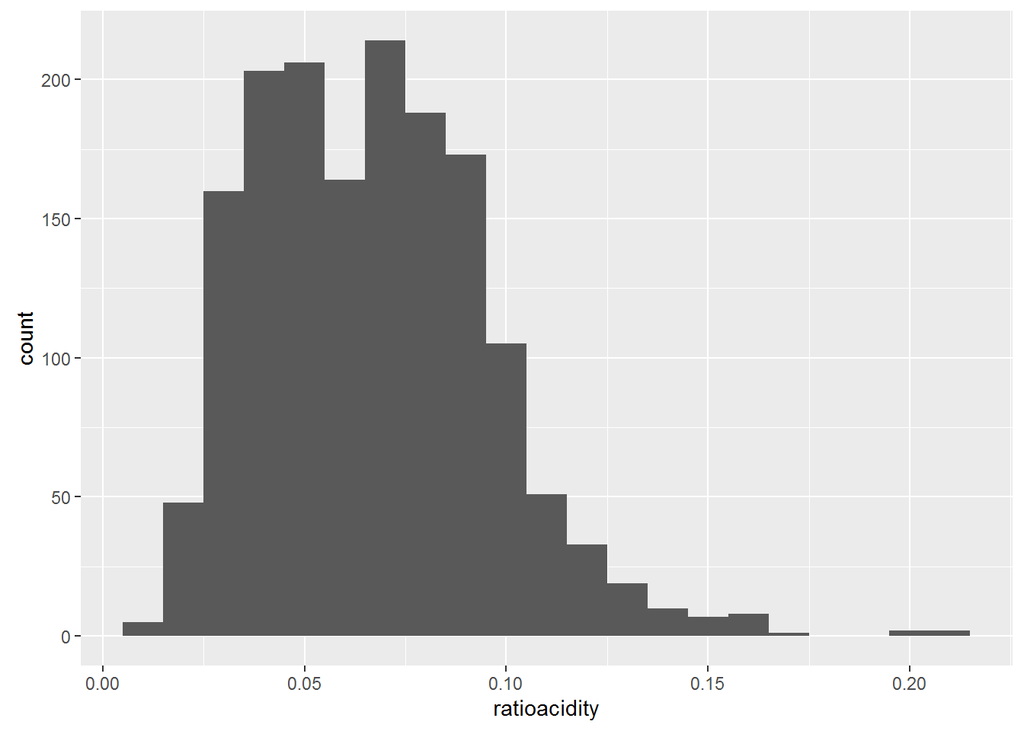

# Univariate Analysis

### What is the structure of your dataset?

(worst—–>best) quality:3,4,5,6,7,8

Observations:

Most samples are normal,with scores are 5,6,7 ,the excellent and poor ones are much fewer than normal ones.The median quality score is 6.The distribution of quality scores is normal distribution.

Almost all features except citric.acid are normal like distribution, or are right skewed can be transformed to normal like distribution using log10. citric.acid looks like a uniform distribution.

### What is/are the main feature(s) of interest in your dataset?

I want to study on the relationship between quality score and physicochemical properties. I think excellent wine may have low volatile acidity, high citric acid. Other properties may also have some influence on quality.But I think there is no dominant factors to determine wine quality, it must be lots properties synthetically result in quality.

### What other features in the dataset do you think will help support your investigation into your feature(s) of interest?

I think there is no dominant factors to determine wine quality, it must be lots properties synthetically result in quality. Later I’ll examine the relationship between each feature and quality.

### Did you create any new variables from existing variables in the dataset?

I tried to create new variables of ratioacidity=volatile acidity/fixed acidity.

### Of the features you investigated, were there any unusual distributions? Did you perform any operations on the data to tidy, adjust, or change the form of the data? If so, why did you do this?

There’re some features are right skewed.Such as free.sulfur.dioxide,total.sulfur.dioxide,alcohol. I used log-transformed to these right skewed features and get normal like distribution.

# Bivariate Plots Section

We examined every 2 features’correlation coefficient.

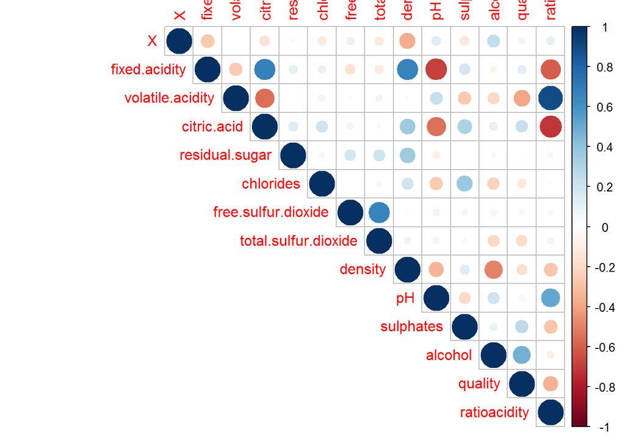

From the corrplot, we found that fixed.acidity and citric.acid ,fixed.acidity and density,free.sulfur.dioxide and total.sulfur.dioxide have high positive correlation.

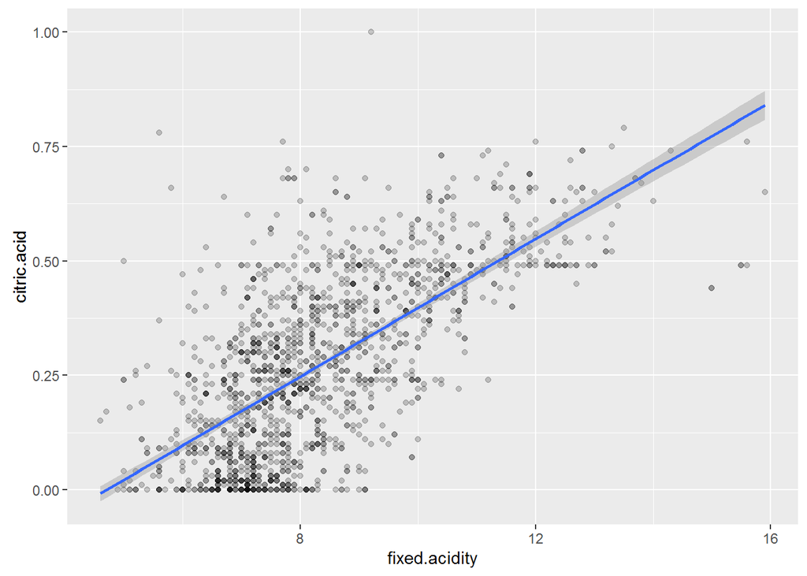

```
##
##  Pearson's product-moment correlation
##
## data:  data$fixed.acidity and data$citric.acid
## t = 36.234, df = 1597, p-value < 2.2e-16
## alternative hypothesis: true correlation is not equal to 0
## 95 percent confidence interval:
##  0.6438839 0.6977493
## sample estimates:
##       cor
## 0.6717034
```

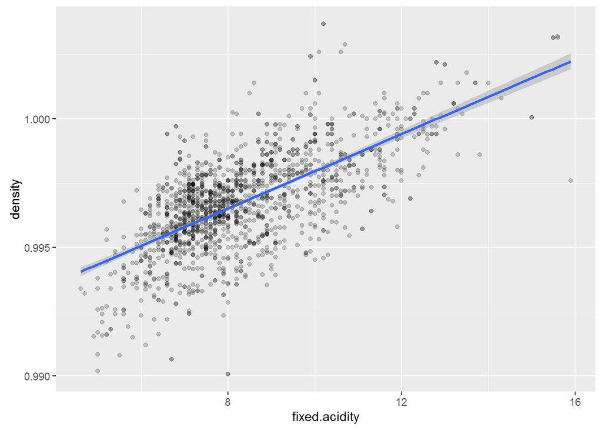

```
##
##  Pearson's product-moment correlation
##
## data:  data$fixed.acidity and data$density
## t = 35.877, df = 1597, p-value < 2.2e-16
## alternative hypothesis: true correlation is not equal to 0
## 95 percent confidence interval:
##  0.6399847 0.6943302
## sample estimates:
##       cor
## 0.6680473
```

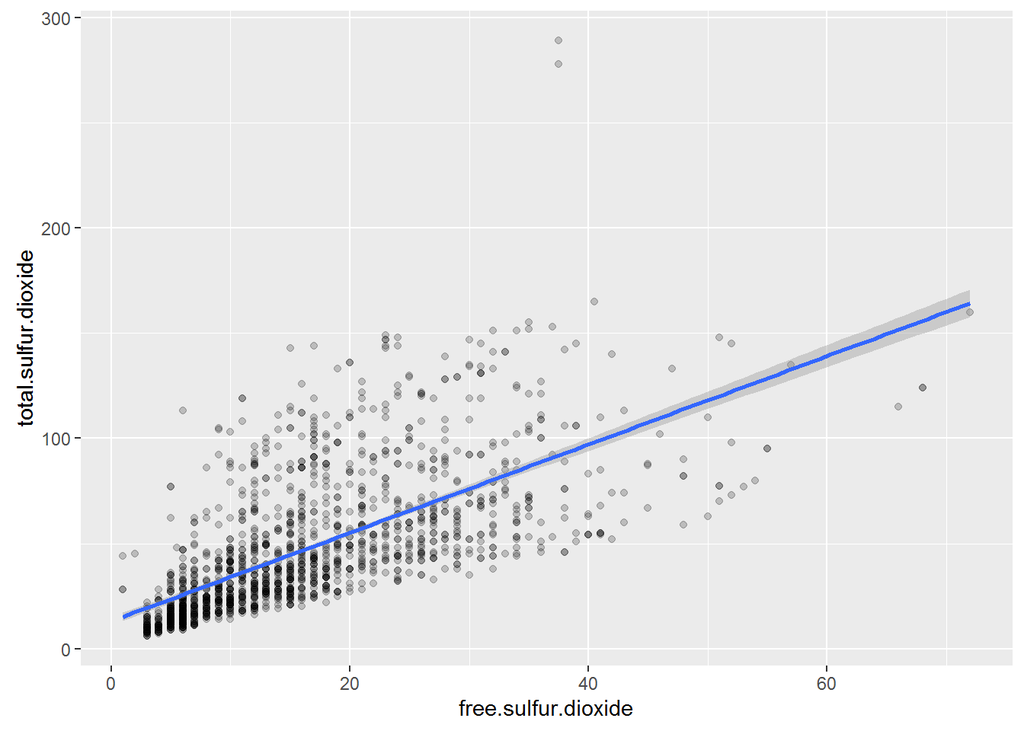

```
##
##  Pearson's product-moment correlation
##
## data:  data$free.sulfur.dioxide and data$total.sulfur.dioxide
## t = 35.84, df = 1597, p-value < 2.2e-16
## alternative hypothesis: true correlation is not equal to 0
## 95 percent confidence interval:
##  0.6395786 0.6939740
## sample estimates:
##       cor
## 0.6676665
```

While fixed.acidity and pH, citric.acid and volatile.acidity,citric.acid and pH have high negtive correlation. Ratioacidity and citric.acid has high negtive correlation.

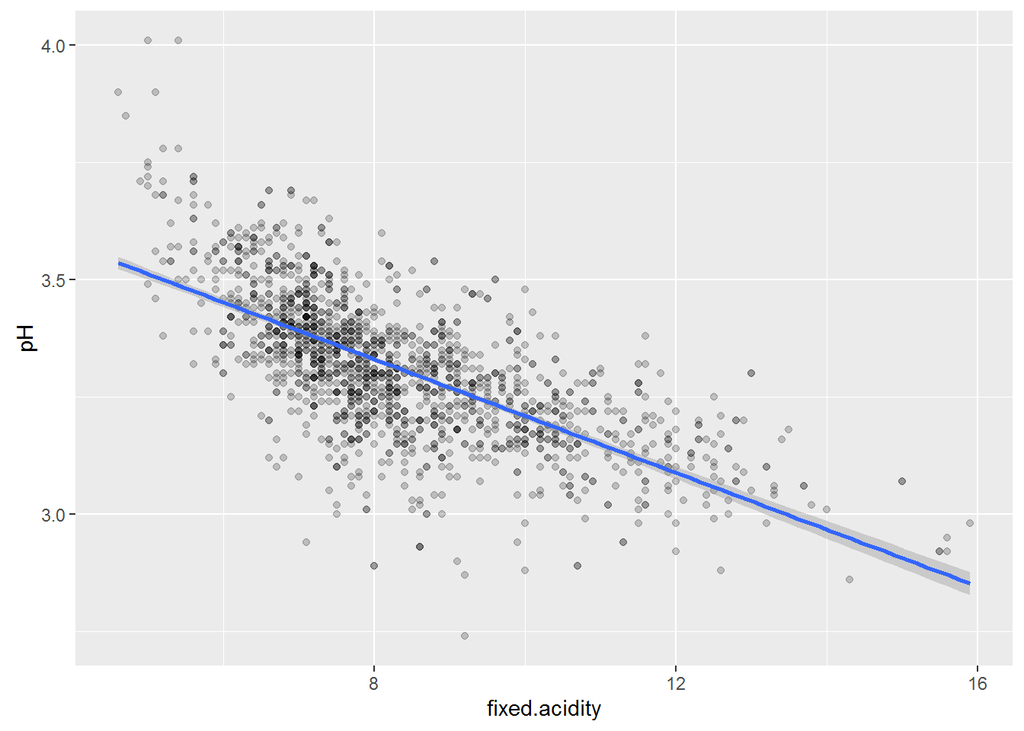

```
##
##  Pearson's product-moment correlation
##
## data:  data$fixed.acidity and data$pH
## t = -37.366, df = 1597, p-value < 2.2e-16
## alternative hypothesis: true correlation is not equal to 0
## 95 percent confidence interval:
##  -0.7082857 -0.6559174
## sample estimates:
##        cor
## -0.6829782
```

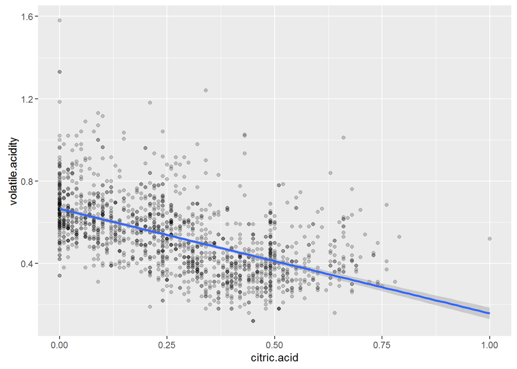

```
##
##  Pearson's product-moment correlation
##
## data:  data$citric.acid and data$volatile.acidity
## t = -26.489, df = 1597, p-value < 2.2e-16
## alternative hypothesis: true correlation is not equal to 0
## 95 percent confidence interval:
##  -0.5856550 -0.5174902
## sample estimates:
##        cor
## -0.5524957
```

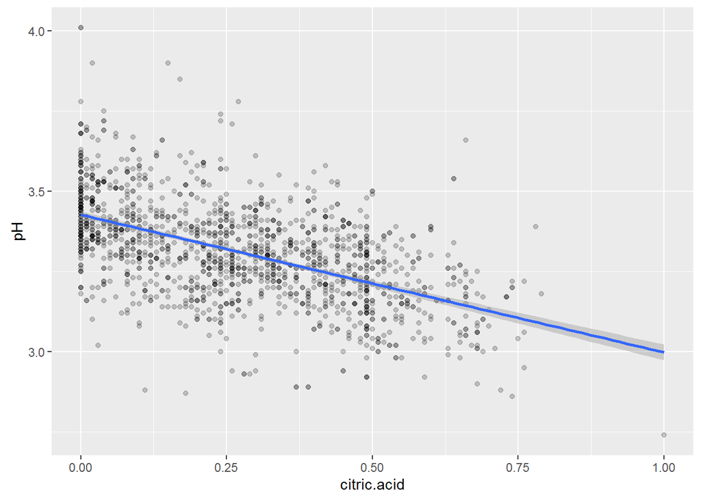

```
##
##  Pearson's product-moment correlation
##
## data:  data$citric.acid and data$pH
## t = -25.767, df = 1597, p-value < 2.2e-16
## alternative hypothesis: true correlation is not equal to 0
## 95 percent confidence interval:
##  -0.5756337 -0.5063336
## sample estimates:
##        cor
## -0.5419041
```

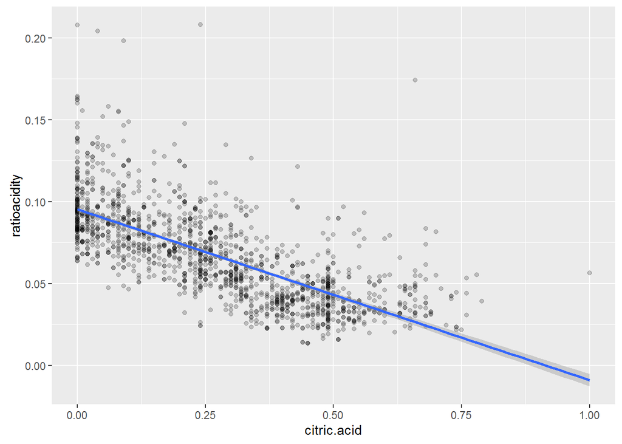

```
##
##  Pearson's product-moment correlation
##
## data:  data$citric.acid and data$ratioacidity
## t = -40.889, df = 1597, p-value < 2.2e-16
## alternative hypothesis: true correlation is not equal to 0
## 95 percent confidence interval:
##  -0.7383035 -0.6903472
## sample estimates:
##       cor
## -0.715166
```

Let’s examine the relationship of median of each variable and quality.Since each variable has different units, we normalize them by scale() and compare the median of normalized variable on each quality in one plot. We can see a very interesting phenomenon that total.sulfur.dioxide and free.sulfur.dioxide firstly increases when quality increases, and when quality reach to 5,they reach the highest value and then go down . So excellent wine and worse wine both have lower total.sulfur.dioxide and free.sulfur.dioxide, while normal wine has higher total.sulfur.dioxide and free.sulfur.dioxide.

Alcohol first goes down with quality increases,and reaches the lowest value when quality is 5,and then goes up with quality increases.

Citric.acid goes up with quality increases.

Sulphates goes up when quality increases.

Fixed.acidity firstly goes up with quality increases and it reaches the highest value when quality is 7,and then goes down when quality increases.

Residual.sugar looks change very slightly with quality increases.

Chlorides goes down with quality increases.

pH goes down with quality increases.

Density goes down with quality increases.

Volatiel.acidity goes down with quality increases.

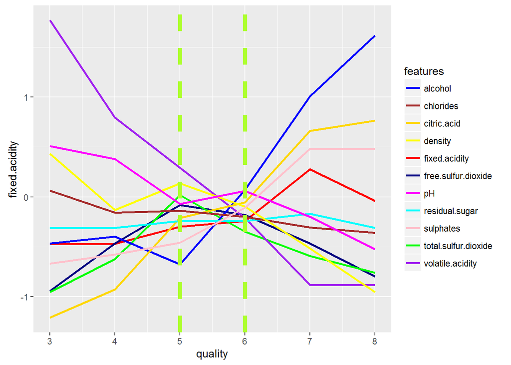

Let’s have a more detail look at the variables from the boxplot. Fixed.acidity median goes up to the top when qualtiy is 7 ,but slightly go down when quality is 8.It has large variance when quanlity is 7 and 8.

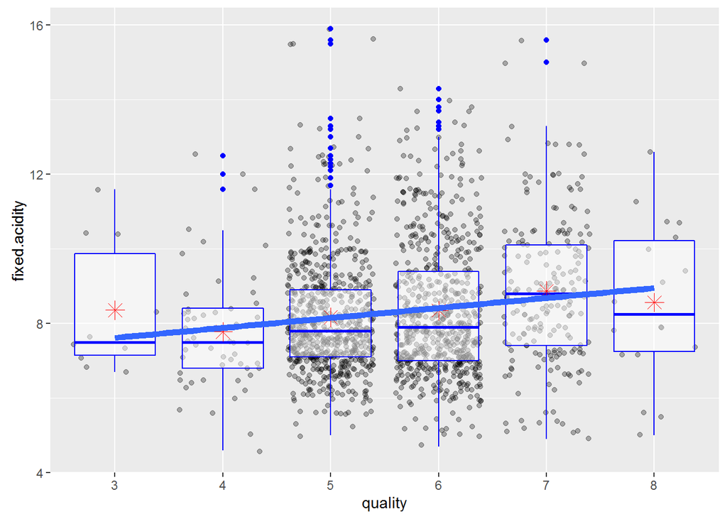

```
##
##  Pearson's product-moment correlation
##
## data:  data$fixed.acidity and data$quality
## t = 4.996, df = 1597, p-value = 6.496e-07
## alternative hypothesis: true correlation is not equal to 0
## 95 percent confidence interval:
##  0.07548957 0.17202667
## sample estimates:
##       cor
## 0.1240516
```

Volatile.acidity decreases when quality increase. High quality wine has lower volatile.acidity.

citric.acid increases when quality increase. High quality wine has high citric.acid.

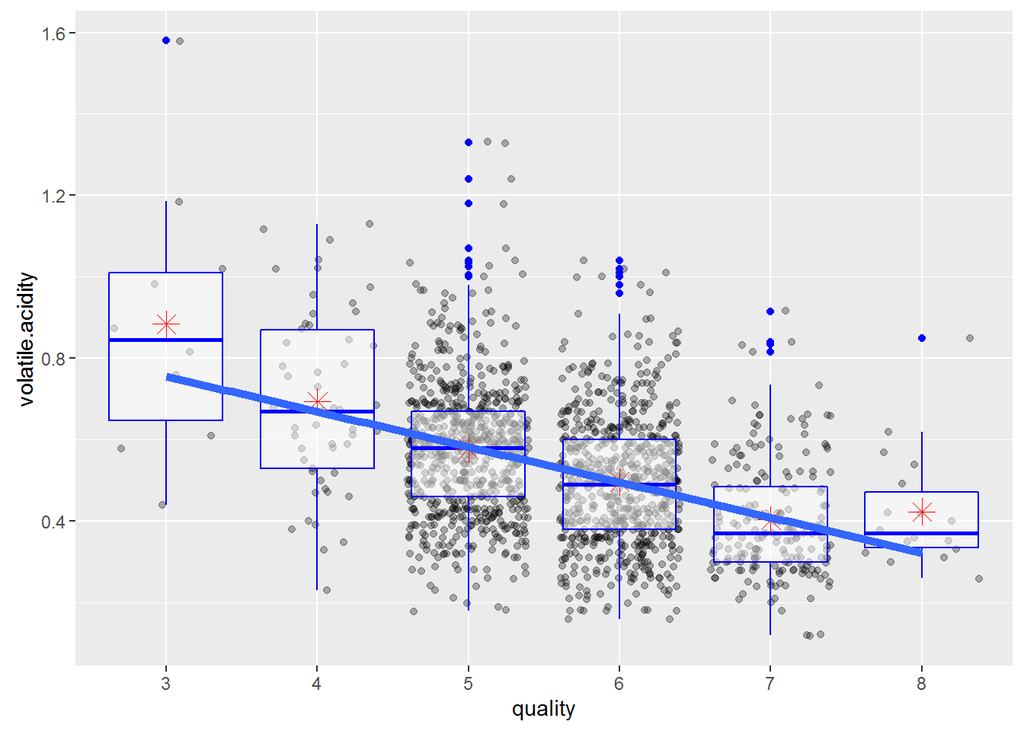

```
##
##  Pearson's product-moment correlation
##
## data:  data$volatile.acidity and data$quality
## t = -16.954, df = 1597, p-value < 2.2e-16
## alternative hypothesis: true correlation is not equal to 0
## 95 percent confidence interval:
##  -0.4313210 -0.3482032
## sample estimates:
##        cor
## -0.3905578
```

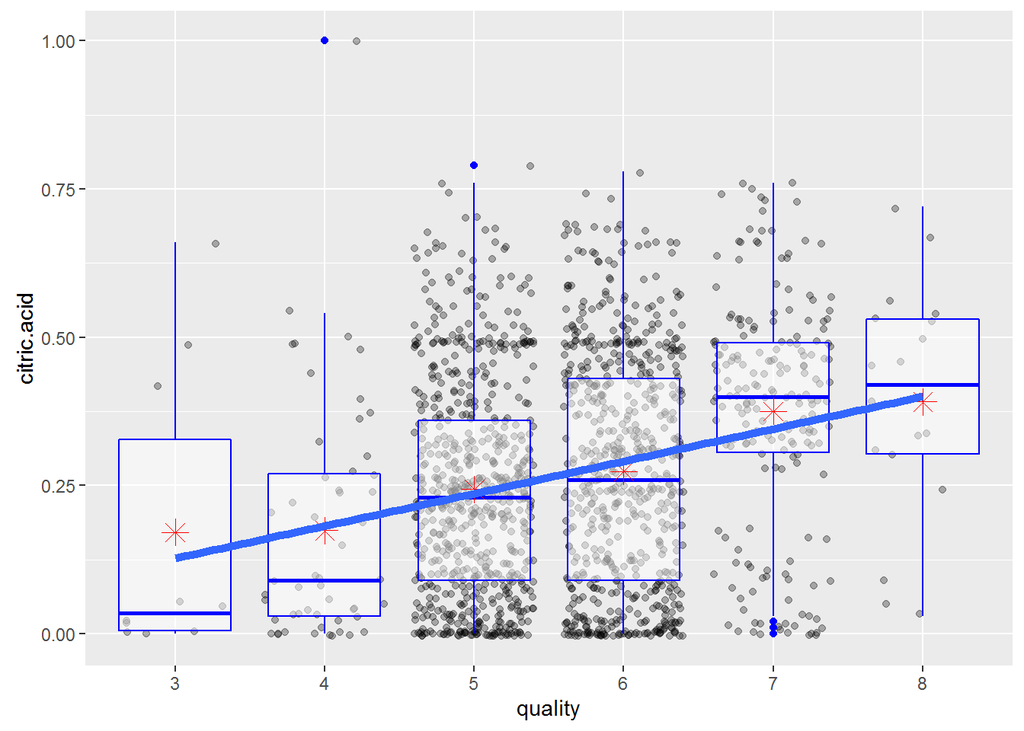

```
##
##  Pearson's product-moment correlation
##
## data:  data$citric.acid and data$quality
## t = 9.2875, df = 1597, p-value < 2.2e-16
## alternative hypothesis: true correlation is not equal to 0
## 95 percent confidence interval:
##  0.1793415 0.2723711
## sample estimates:
##       cor
## 0.2263725
```

Residual.sugar have slightly changes when quality goes up. It seems it not a good predictor variable.

[figure not shown]

```
##
##  Pearson's product-moment correlation
##
## data:  data$residual.sugar and data$quality
## t = 0.5488, df = 1597, p-value = 0.5832
## alternative hypothesis: true correlation is not equal to 0
## 95 percent confidence interval:
##  -0.03531327  0.06271056
## sample estimates:
##        cor
## 0.01373164
```

Chlorides go down when quality increases.

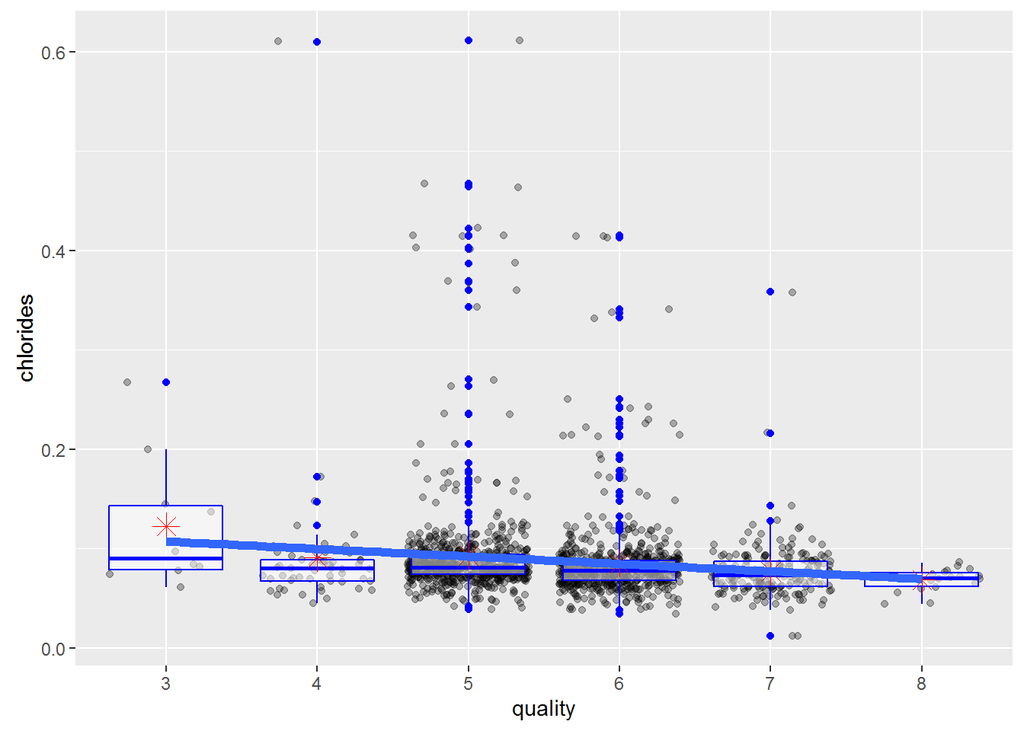

```
##
##  Pearson's product-moment correlation
##
## data:  data$chlorides and data$quality
## t = -5.1948, df = 1597, p-value = 2.313e-07
## alternative hypothesis: true correlation is not equal to 0
## 95 percent confidence interval:
##  -0.17681041 -0.08039344
## sample estimates:
##        cor
## -0.1289066
```

Free.sulfur.dioxide and total.sulfur.dioxide firstly go up when quality increases from bad wine to normal wine. They reach the highest value when quality is 5, and then they go down with quality increases from normal wine to excellent wind. Attention that since the majority of samples have quality 5,6,7, the regression line is dominated by the majority of samples and slightly impacted by samples which quality are 3,4,8. That’s why you can only see the regression line have negetive correlation coefficient.

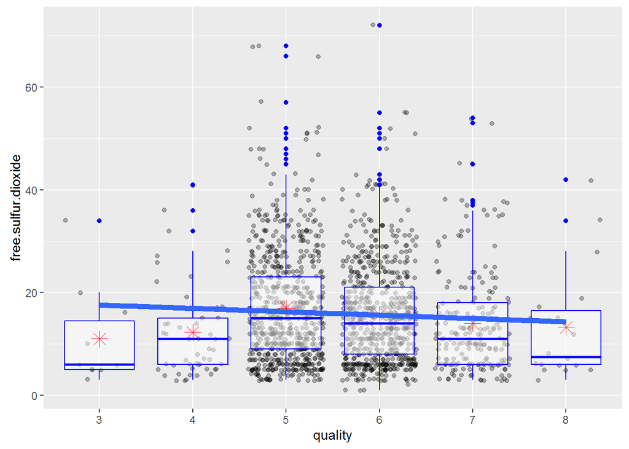

```
##
##  Pearson's product-moment correlation
##
## data:  data$free.sulfur.dioxide and data$quality
## t = -2.0269, df = 1597, p-value = 0.04283
## alternative hypothesis: true correlation is not equal to 0
## 95 percent confidence interval:
##  -0.099430290 -0.001638987
## sample estimates:
##         cor
## -0.05065606
```

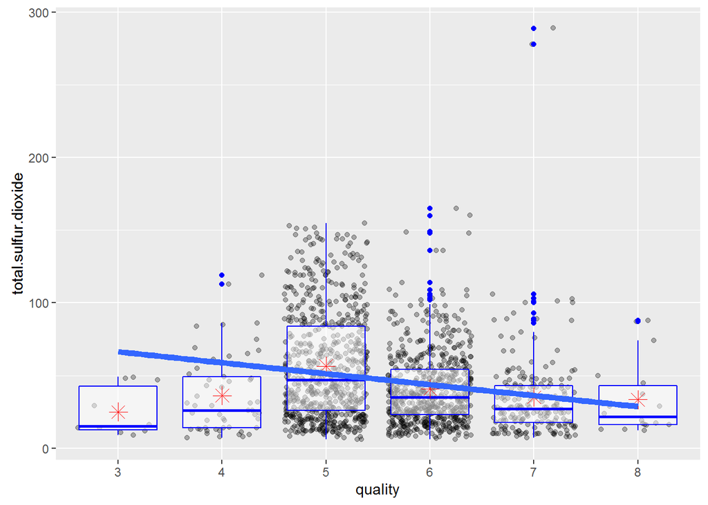

```
##
##  Pearson's product-moment correlation
##
## data:  data$total.sulfur.dioxide and data$quality
## t = -7.5271, df = 1597, p-value = 8.622e-14
## alternative hypothesis: true correlation is not equal to 0
## 95 percent confidence interval:
##  -0.2320162 -0.1373252
## sample estimates:
##        cor
## -0.1851003
```

Density and pH and ratioacidity go down when quality increases.